# R Notebook

The following example shows how one can create quite complicated data structures by using list objects as components inside a list.

```r
spec.list <- vector(mode = "list", length = 3)

names(spec.list) <- c("O2", "H2O", "CO2")

spec.list$O2  <- list(name = "oxygen", mol.weight = 32)
spec.list$H2O <- list(name = "water", mol.weight = 18)
spec.list$CO2 <- list(name = "carbon dioxide", mol.weight = 44)

spec.list
```

```
## $O2
## $O2$name
## [1] "oxygen"
##
## $O2$mol.weight
## [1] 32
##
##
## $H2O
## $H2O$name
## [1] "water"
##
## $H2O$mol.weight
## [1] 18
##
##
## $CO2
## $CO2$name
## [1] "carbon dioxide"
##
## $CO2$mol.weight
## [1] 44
```

The names() command initializes the names of the mother list. Each daughter component of the mother list is in itself again a list object. Print spec.list on the screen and try to understand its contents.

## Plotting a mathematical function

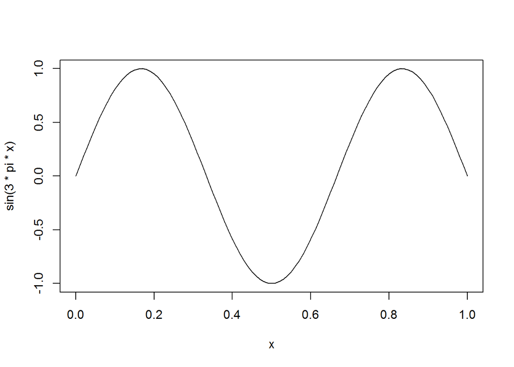

```r
# 1st plot
curve(expr = sin(3*pi*x))
```

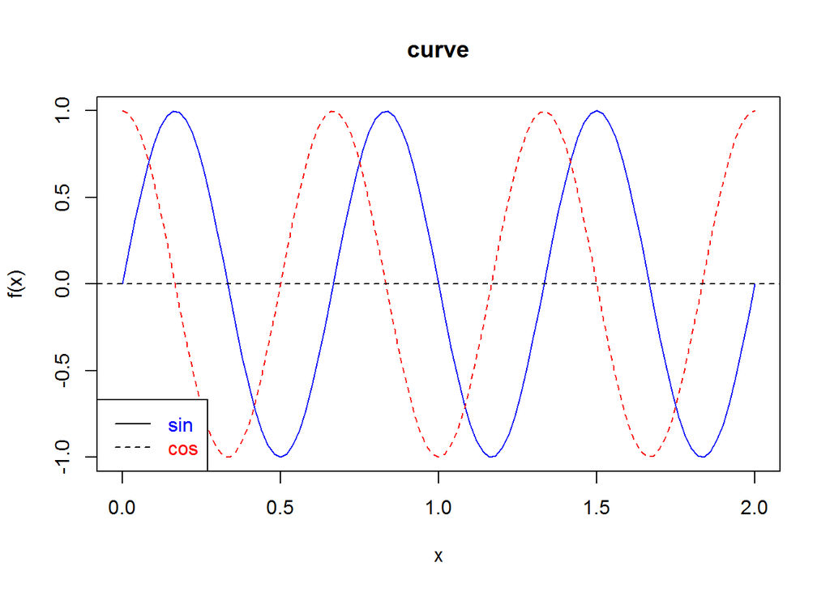

```r
# 2nd set of plots
curve(expr = sin(3*pi*x), from = 0, to = 2, col = "blue",
      xlab = "x", ylab = "f(x)", main = "curve")

curve(expr = cos(3*pi*x), add = TRUE, col = "red", lty = 2)
abline(h = 0, lty = 2)

# add legend
legend("bottomleft", c("sin", "cos"),
text.col = c("blue", "red"), lty = 1:2)
```

## Root of functions

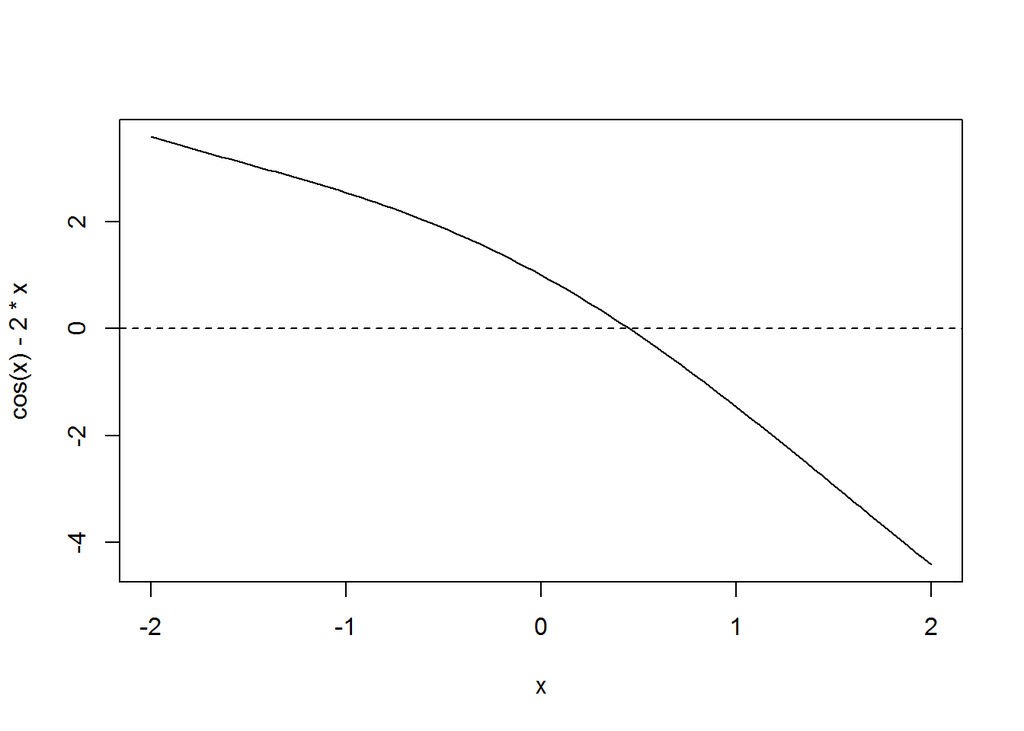

```r
curve(expr = cos(x)-2*x, from = -2, to = 2)
abline(h = 0, lty = 2)
```

## 9.2. The bisection method

The bisection method is a basic root-ﬁnding method. It is simple and robust, but also rather slow. In real life problems, other methods will be preferred that are numerically more eﬃcient. However, the bisection method nicely illustrates how a root algotithm works, and for this reason, we discuss it here. We start from an interval [a, b] for which we know that it contains a root. The bisection method then divides this interval in two and selects the subinterval in which a root must lie. This procedure is repeated until the interval is suﬃciently small (i.e. smaller than some preset tolerance). The bisection method can be implented by following function:

```r
bisection <- function(f, interval, tol=.Machine$double.eps^0.25, maxiter=1000)
{
  a <- interval[1]
  b <- interval[2]
  if (a >= b) stop("startpoint a must be smaller than endpoint b")
  if (f(a)*f(b) >= 0) stop("f(a) and f(b) must have a different sign")
  i <- 1
  while (i <= maxiter) #limit iterations to prevent infinite loop
  {
  mid <- (a + b)/2 # new midpoint
  estim.prec <- (b - a)/2 # estimated precision
  if (f(mid) == 0 | estim.prec < tol) # root found
  {
  if (f(mid) == 0) estim.prec <- 0
  result <- list(root=mid,f.root=f(mid),iter=i,estim.prec=estim.prec)
  return(result)
  }
  i <- i + 1 # step counter increases
  if (sign(f(mid)) == sign(f(a))) a <- mid else b <- mid
  }
  stop(paste("Bisection method failed: max number of steps",maxiter,"exceeded"))
}
```

The bisection method requires four diﬀerent types of input: * f: the function for which the root needs to be found * interval: the interval speciﬁed by the start point a and the end point b. The start point must be smaller than the end point, and the function f needs to have an opposite sign at these two points. * tol: the requested tolerance on the root. If no value is speciﬁed, we use a default value based on the machine precision .Machine$double.eps * maxiter: the maximum number of iterations. This criterion is speciﬁed to prevent that the algorithm gets stuck in an inﬁnite loop.

The bisection method generates four diﬀerent types of output: * root: the estimated value of the root * f.root: the function value evaluated at the root * iter: the number of iterations used * estim.prec: an estimate of the precision for the root

```r
test.f <- function(x) return(cos(x)-2*x)
(result <- bisection(f = test.f, interval = c(-2, 2)))
```

```
## $root
## [1] 0.4501343
##
## $f.root
## [1] 0.0001201335
##
## $iter
## [1] 16
##
## $estim.prec
## [1] 6.103516e-05
```

## 11. Diﬀerential equations

In the natural sciences, the challenge is often to describe or predict how a given environmental variable will evolve over time. Depending on the problem at hand, this variable can have many diﬀerent meanings. For example, one could be interested in future evolution of the temperature of the atmosphere (as in the IPCC models of global warming), the seasonal ﬂuctuation in the oxygen concentration in a lake (as described in biogeochemical ecosystem models), or the year-to-year ﬂuctuations in the density of lions in the Serengeti National park (as in the population models used by conservation biologists). The mathematical models that describe such changes in environmental variable are called dynamic models, because they have the time t as the independent variable. The models themselves are based on diﬀerential equations, which are typically of the form:

$$\frac {dC}{dt} = f(a, b(t), C = f(C, t)$$
In this, $t$ represents the time and $C$ is the `state variable`. Furthermore, $a$ is a parameter that remains constant in time, while $b(t)$ is a function that varies with time (a so-called **forcing function**). This equation is termed a diﬀerential equation because it contains the derivative $dC/dt$, which represents the so-called `rate of change` of the `state variable` $C$ . The speciﬁc form of the function f depends on the physical, chemical and biological processes that inﬂuence $C$.